# **R Session n°2 - practical: version with corrections**

M1 MEG UE5 - Claire Vandiedonck

*Programme couvert:*

- Les matrices et leur manipulation

**Rappels**

> Les exercices proposés sont donnés dans un ordre progressif qui suit celui du diaporama associé. Ils ont des niveaux de difficulté variable. Pour chaque exercice, des fonctions R vous sont suggérées. N’hésitez pas à consulter leur menu d’aide en tapant soit `?nom_fonction`, soit `help(nom_fonction)`. Vous pouvez parvenir aux mêmes résultats avec d’autres commandes. Les commandes les plus courtes sont en général les meilleures. Une correction détaillée sera fournie.

> Vous pouvez réaliser ces exercices directement dans ce notebook sur `adenine` en indiquant votre code dans les cellules laissées libres. Pour ajouter une nouvelle cellule, cliquez simplement sur le `+`dans le menu en haut à gauche du notebook (cf. rappels sur les notebooks en bas de ce notebook). Vous pouvez mettre plusieurs lignes de code aussi par cellule. Pour executer les cellules, cliquez sur `Shift+Enter`. Executez les dans le bon ordre. Remarque: dans un notebook jupyter, l'affichage des vecteurs n'est pas classique. Si vous souhaitez afficher le vecteur de façon plus classique, c'est à dire en ligne avec l'indice pour la 1ère valeur de chaque ligne au début de la ligne, tel qu'il apparait dans R, il est nécessaire d'utiliser la fonction `print()` -> voir dans cet exemple avec un vecteur contenant les deux valeurs numériques 1 et 10.

```r
my_vector <- c(1, 10) # pour générer le vecteur et l'assigner dans un objet "my_vector"
my_vector # l'affichage ici montre deux éléments dont l'affichage est séparé par un point médian.
```

1. 1

2. 10

```r
print(my_vector) # L'affichage ici montre le vecteur par ligne avec l'indice 1 entre crochets indiquant l'indice de la première valeur de la ligne.
```

```
[1]  1 10
```

> Vous pouvez également réaliser ces exercices si vous le préférez dans un terminal ou une console de cet environnement `megm1_ue5_r` sur adenine, ou sur la version rstudio de cet environnement.

> Il est enfin possible de réaliser ces exercices sur votre ordinateur. Dans ce cas, utilisez un editeur de texte avec coloration syntaxique pour votre code (editeur dans Rstudio, ou Tinn-R ou notepad++ par exemple). Sauvegardez vos commandes dans un fichier mes_commandes.R dans le répertoire de votre choix. Exécutez les commandes une par une dans votre console. Vous pouvez ajouter des commentaires qui ne seront pas éxécutés si vous les précédez du caractère « # ».

## Avant d'aller plus loin

**Attention:** Ne travaillez pas directement sur ce notebook pour ne pas le perdre. Dupliquez-le et renommez-le par exemple en ajoutant vos initiales et travaillez sur cette nouvelle copie. Pour ce faire, dans le panneau de gauche, faites un clic droit sur le fichier et sélectionnez "Duplicate". Puis, toujours dans la colonne de gauche, faites un clic droit sur cette copie et sélectionnez "rename" pour changer le nom. Ouvrez ensuite cette nouvelle version en double cliquant dessus. Vous êtes prêt(e) à démarrer!  
**N'oubliez pas de sauvegarder régulièrement votre notebook**: `Ctrl` + `S`. ou en cliquant sur l'icone 💾 en haut à gauche de votre notebook ou dans le Menu du JupyterLab "File puis "Save Notebook"! Vous pouvez aussi le sauvegarder au format html: Menu "File" > Export Notebook As> Export notebook as HTML.

Do not hesitate to try other commands by adding other cells. cf useful commands at the bottom of the notebook

**Open variable inspector:** right click on the notebook and select "Open Variable Inspector". A new tab will open.

#### 1. Identifiez votre répertoire de travail

```r
getwd()
```

'/srv/home/cvandiedonck/megm1_ue5_r/R2'

Si ce répertoire ne vous convient pas, changer le pour un répertoire existant `my_directory`par exemple, avec la commande suivante en spécifiant le chemin relatif ou absolu de votre répertoire: `setwd("path/my_directory")`

## Exercice 1 : création de matrices

### Execrice 1.1

Créez la matrice identité `matIdentite` de dimension 10 lignes x 10 colonnes contenant uniquement le chiffre 0. Affichez là.

**Tip :** *fonction recommandée : `matrix()`*

```r
matIdentite <- matrix(data = 0, ncol = 10, nrow = 10)
matIdentite
```

A matrix: 10 × 10 of type dbl

| 0 | 0 | 0 | 0 | 0 | 0 | 0 | 0 | 0 | 0 |
| --- | --- | --- | --- | --- | --- | --- | --- | --- | --- |
| 0 | 0 | 0 | 0 | 0 | 0 | 0 | 0 | 0 | 0 |
| 0 | 0 | 0 | 0 | 0 | 0 | 0 | 0 | 0 | 0 |
| 0 | 0 | 0 | 0 | 0 | 0 | 0 | 0 | 0 | 0 |
| 0 | 0 | 0 | 0 | 0 | 0 | 0 | 0 | 0 | 0 |
| 0 | 0 | 0 | 0 | 0 | 0 | 0 | 0 | 0 | 0 |
| 0 | 0 | 0 | 0 | 0 | 0 | 0 | 0 | 0 | 0 |
| 0 | 0 | 0 | 0 | 0 | 0 | 0 | 0 | 0 | 0 |
| 0 | 0 | 0 | 0 | 0 | 0 | 0 | 0 | 0 | 0 |
| 0 | 0 | 0 | 0 | 0 | 0 | 0 | 0 | 0 | 0 |

Puis remplacez uniquement les valeurs de la diagonale par le chiffre 1.

**Tip :** *fonction recommandée : `diag()`*

```r
diag(matIdentite) <- 1 #diag() retourne un vecteur dont on peut remplacer les valeurs 0 par 1
```

Imprimez la matrice à l’écran.

**Tip :** *fonction recommandée : `print()`*

```r
print(matIdentite)
```

```
      [,1] [,2] [,3] [,4] [,5] [,6] [,7] [,8] [,9] [,10]
 [1,]    1    0    0    0    0    0    0    0    0     0
 [2,]    0    1    0    0    0    0    0    0    0     0
 [3,]    0    0    1    0    0    0    0    0    0     0
 [4,]    0    0    0    1    0    0    0    0    0     0
 [5,]    0    0    0    0    1    0    0    0    0     0
 [6,]    0    0    0    0    0    1    0    0    0     0
 [7,]    0    0    0    0    0    0    1    0    0     0
 [8,]    0    0    0    0    0    0    0    1    0     0
 [9,]    0    0    0    0    0    0    0    0    1     0
[10,]    0    0    0    0    0    0    0    0    0     1
```

**=> Pour aller plus loin :** 2 variantes plus efficaces pour créer la matrice :

```r
cat("------variante 1:\n")
print(diag(1,10,10))
```

```
------variante 1:
      [,1] [,2] [,3] [,4] [,5] [,6] [,7] [,8] [,9] [,10]
 [1,]    1    0    0    0    0    0    0    0    0     0
 [2,]    0    1    0    0    0    0    0    0    0     0
 [3,]    0    0    1    0    0    0    0    0    0     0
 [4,]    0    0    0    1    0    0    0    0    0     0
 [5,]    0    0    0    0    1    0    0    0    0     0
 [6,]    0    0    0    0    0    1    0    0    0     0
 [7,]    0    0    0    0    0    0    1    0    0     0
 [8,]    0    0    0    0    0    0    0    1    0     0
 [9,]    0    0    0    0    0    0    0    0    1     0
[10,]    0    0    0    0    0    0    0    0    0     1
```

```r
cat("------variante 2:\n")
print(diag(10))# en fait, par defaut, si on n'utilise qu'un seul argument dans la fonction diag(), la commande retourne une matrice de 0 sauf pour la diagonale contenant des 1
```

```
------variante 2:
      [,1] [,2] [,3] [,4] [,5] [,6] [,7] [,8] [,9] [,10]
 [1,]    1    0    0    0    0    0    0    0    0     0
 [2,]    0    1    0    0    0    0    0    0    0     0
 [3,]    0    0    1    0    0    0    0    0    0     0
 [4,]    0    0    0    1    0    0    0    0    0     0
 [5,]    0    0    0    0    1    0    0    0    0     0
 [6,]    0    0    0    0    0    1    0    0    0     0
 [7,]    0    0    0    0    0    0    1    0    0     0
 [8,]    0    0    0    0    0    0    0    1    0     0
 [9,]    0    0    0    0    0    0    0    0    1     0
[10,]    0    0    0    0    0    0    0    0    0     1
```

### Exercice 1.2.

Créez une matrice `matAleatoire` contenant des valeurs tirées aléatoirement de dimension 10 lignes x 10 colonnes, dont les éléments suivent une loi normale de moyenne 0 et de variance 5.

Imprimez la matrice à l’écran en arrondissant à 2 décimales.

**Tip :** *fonction recommandée : `matrix()`, `print()`, `rnorm()`, `round()`*

```r
## Generate a 10x10 matrix with random normal numbers
matAleatoire <- matrix(
  nrow = 10,
  ncol = 10,
  data = rnorm(n = 100,
               mean = 0,
               sd = sqrt(5)))
# as long as you specify the arguments, you may change the order to pass the arguments to the function
```

```r
## Print the results rounded at 2 decimals
print(round(matAleatoire, digits = 2))
```

```
       [,1]  [,2]  [,3]  [,4]  [,5]  [,6]  [,7]  [,8]  [,9] [,10]
 [1,] -3.21 -5.36  0.36  0.17 -4.59 -4.50  3.20  1.07 -2.40 -1.24
 [2,] -0.58 -2.78  0.72  2.15 -1.48 -3.13 -2.27 -0.65 -0.16  2.76
 [3,]  3.16 -0.75  1.50 -2.65  0.77  1.99  1.59  1.90 -0.08 -1.62
 [4,]  1.54 -2.26  5.25  0.87  1.06  1.08 -0.36  2.36  2.19  2.04
 [5,]  0.52 -2.41  1.34 -0.51  1.53 -1.13 -0.29  1.36  1.20  0.23
 [6,] -0.82  2.61 -1.85 -0.89  1.60 -4.01  4.55 -1.11  0.86  0.67
 [7,] -0.70  0.76  1.45 -1.57 -1.84 -1.37  3.07 -0.48  3.79  1.09
 [8,]  2.86 -0.78  0.72 -7.16  3.33 -3.50 -0.43  1.14 -3.88 -2.52
 [9,]  2.11  2.00 -1.65  1.52 -0.14  0.91 -1.78 -2.81 -0.45 -4.33
[10,] -0.12 -0.41 -1.88  3.16  2.25 -0.93 -0.14 -2.98  0.10 -0.34
```

### Exercice 1.3.

Créez un vecteur `vec1` contenant les lettres de l'alphabet en minuscules et un vecteur `vec2` contenant les lettres de l'aphabet en majuscules.

**Tip :** *constantes recommandées : `letters`, `LETTERS`*

```r
vec1 <- letters
vec2 <- LETTERS
vec1
vec2
```

1. 'a'

2. 'b'

3. 'c'

4. 'd'

5. 'e'

6. 'f'

7. 'g'

8. 'h'

9. 'i'

10. 'j'

11. 'k'

12. 'l'

13. 'm'

14. 'n'

15. 'o'

16. 'p'

17. 'q'

18. 'r'

19. 's'

20. 't'

21. 'u'

22. 'v'

23. 'w'

24. 'x'

25. 'y'

26. 'z'

1. 'A'

2. 'B'

3. 'C'

4. 'D'

5. 'E'

6. 'F'

7. 'G'

8. 'H'

9. 'I'

10. 'J'

11. 'K'

12. 'L'

13. 'M'

14. 'N'

15. 'O'

16. 'P'

17. 'Q'

18. 'R'

19. 'S'

20. 'T'

21. 'U'

22. 'V'

23. 'W'

24. 'X'

25. 'Y'

26. 'Z'

Créez une matrice `my_mat` vide de 26 colonnes et 2 lignes.

Remplacez les données manquantes de la matrice par les vecteurs `vec1` et `vec2` en lignes.

**Tip :** *fonction recommandée : `matrix()`, `print()`*

```r
my_mat <- matrix (NA, nrow = 2, ncol = 26)
my_mat[1,] <- vec1
my_mat[2,] <- vec2
my_mat
```

A matrix: 2 × 26 of type chr

| a | b | c | d | e | f | g | h | i | j | ⋯ | q | r | s | t | u | v | w | x | y | z |
| --- | --- | --- | --- | --- | --- | --- | --- | --- | --- | --- | --- | --- | --- | --- | --- | --- | --- | --- | --- | --- |
| A | B | C | D | E | F | G | H | I | J | ⋯ | Q | R | S | T | U | V | W | X | Y | Z |

**=> Pour aller plus loin :**

```r
my_mat <- matrix (data = c(vec1, vec2), nrow = 2)
my_mat
```

A matrix: 2 × 26 of type chr

| a | c | e | g | i | k | m | o | q | s | ⋯ | G | I | K | M | O | Q | S | U | W | Y |
| --- | --- | --- | --- | --- | --- | --- | --- | --- | --- | --- | --- | --- | --- | --- | --- | --- | --- | --- | --- | --- |
| b | d | f | h | j | l | n | p | r | t | ⋯ | H | J | L | N | P | R | T | V | X | Z |

Essayez de nouveau de créer la matrice `my_mat` sans utiliser la fonction `matrix()`, directement à partir des vecteurs vec1 et vec2.

**Tip :** *fonction recommandée : `rbind()`*

```r
my_mat <- rbind(vec1, vec2)
my_mat
```

A matrix: 2 × 26 of type chr

| vec1 | a | b | c | d | e | f | g | h | i | j | ⋯ | q | r | s | t | u | v | w | x | y | z |
| --- | --- | --- | --- | --- | --- | --- | --- | --- | --- | --- | --- | --- | --- | --- | --- | --- | --- | --- | --- | --- | --- |
| vec2 | A | B | C | D | E | F | G | H | I | J | ⋯ | Q | R | S | T | U | V | W | X | Y | Z |

Créez à présent la matrice `my_mat2` avec les mêmes vecteurs `vec1` et `vec2` mais avec 26 lignes et 2 colonnes.

**Tip :** *fonction recommandée : `cbind()`*

```r
my_mat2 <- cbind(vec1, vec2)
my_mat2
```

A matrix: 26 × 2 of type chr

| vec1 | vec2 |
| --- | --- |
| a | A |
| b | B |
| c | C |
| d | D |
| e | E |
| f | F |
| g | G |
| h | H |
| i | I |
| j | J |
| k | K |
| l | L |
| m | M |
| n | N |
| o | O |
| p | P |
| q | Q |
| r | R |
| s | S |
| t | T |
| u | U |
| v | V |
| w | W |
| x | X |
| y | Y |
| z | Z |

Renommez les colonnes de `my_mat2` par "Min" et "Maj". Affichez la matrice.

**Tip :** *fonction recommandée : `colnames()`*

```r
colnames(my_mat2) <- c("Min", "Man")
print(my_mat2)
```

```
      Min Man
 [1,] "a" "A"
 [2,] "b" "B"
 [3,] "c" "C"
 [4,] "d" "D"
 [5,] "e" "E"
 [6,] "f" "F"
 [7,] "g" "G"
 [8,] "h" "H"
 [9,] "i" "I"
[10,] "j" "J"
[11,] "k" "K"
[12,] "l" "L"
[13,] "m" "M"
[14,] "n" "N"
[15,] "o" "O"
[16,] "p" "P"
[17,] "q" "Q"
[18,] "r" "R"
[19,] "s" "S"
[20,] "t" "T"
[21,] "u" "U"
[22,] "v" "V"
[23,] "w" "W"
[24,] "x" "X"
[25,] "y" "Y"
[26,] "z" "Z"
```

Donnez un nom aux lignes correspondant à la position dans l'alphabet à partir d'un vecteur numérique vec3. Affichez la matrice et vérifiez qu'il s'agit toujours bien d'une matrice.

**Tip :** *fonction recommandée : `:`, `rownames()`, `class()`*

```r
vec3 <- 1:26
rownames(my_mat2) <- vec3
my_mat2
class(my_mat2)
```

A matrix: 26 × 2 of type chr

|  | Min | Man |
| --- | --- | --- |
| 1 | a | A |
| 2 | b | B |
| 3 | c | C |
| 4 | d | D |
| 5 | e | E |
| 6 | f | F |
| 7 | g | G |
| 8 | h | H |
| 9 | i | I |
| 10 | j | J |
| 11 | k | K |
| 12 | l | L |
| 13 | m | M |
| 14 | n | N |
| 15 | o | O |
| 16 | p | P |
| 17 | q | Q |
| 18 | r | R |
| 19 | s | S |
| 20 | t | T |
| 21 | u | U |
| 22 | v | V |
| 23 | w | W |
| 24 | x | X |
| 25 | y | Y |
| 26 | z | Z |

1. 'matrix'

2. 'array'

**=> Pour aller plus loin :**

On peut ommer directement les colonnes au moment de la création de la matrice avec `cbind()`. L'attribut de `vec1` est utilisé en nom de ligne.

```r
names(vec1) <- 1:26
my_mat2 <- cbind("Min" = vec1, "Maj"= vec2)
my_mat2
str(my_mat2)
```

A matrix: 26 × 2 of type chr

|  | Min | Maj |
| --- | --- | --- |
| 1 | a | A |
| 2 | b | B |
| 3 | c | C |
| 4 | d | D |
| 5 | e | E |
| 6 | f | F |
| 7 | g | G |
| 8 | h | H |
| 9 | i | I |
| 10 | j | J |
| 11 | k | K |
| 12 | l | L |
| 13 | m | M |
| 14 | n | N |
| 15 | o | O |
| 16 | p | P |
| 17 | q | Q |
| 18 | r | R |
| 19 | s | S |
| 20 | t | T |
| 21 | u | U |
| 22 | v | V |
| 23 | w | W |
| 24 | x | X |
| 25 | y | Y |
| 26 | z | Z |

```
 chr [1:26, 1:2] "a" "b" "c" "d" "e" "f" "g" "h" "i" "j" "k" "l" "m" "n" ...
 - attr(*, "dimnames")=List of 2
  ..$ : chr [1:26] "1" "2" "3" "4" ...
  ..$ : chr [1:2] "Min" "Maj"
```

## Exercice 2 : manipulation de matrices

### Exercice 2.1

Créez deux vecteurs aléatoires nommés `x1` et `x2`, contenant chacun n=10.000 valeurs aléatoires respectivement compatibles:

- avec une loi normale centrée réduite (cad de moyenne 0 et d'écrat type 1) pour x1;
- avec une loi uniforme définie sur l’intervalle [0,10] pour x2.

**Tip :** *fonctions recommandées : `rnorm()`, `runif()`*

```r
n <- 10000 ## define vector sizes => cette étape n'est pas indispensable, vous pouvez directement rentrer la valeur 10000 dans les commandes-ci-dessous
```

```r
x1 <- rnorm(n = n, mean = 0, sd = 1) ## normal random
x2 <- runif(n = n, min = 0, max = 10) ## uniform random
```

**=> Pour aller plus loin :**

On anticipe sur la session sur les figures. Vérifiez la distribution empirique de ces échantillons en dessinant des histogrammes.

```
+++ distribution normale :
```

```
     Min.   1st Qu.    Median      Mean   3rd Qu.      Max.
-3.786025 -0.672080  0.003687  0.000625  0.676230  4.263663
```

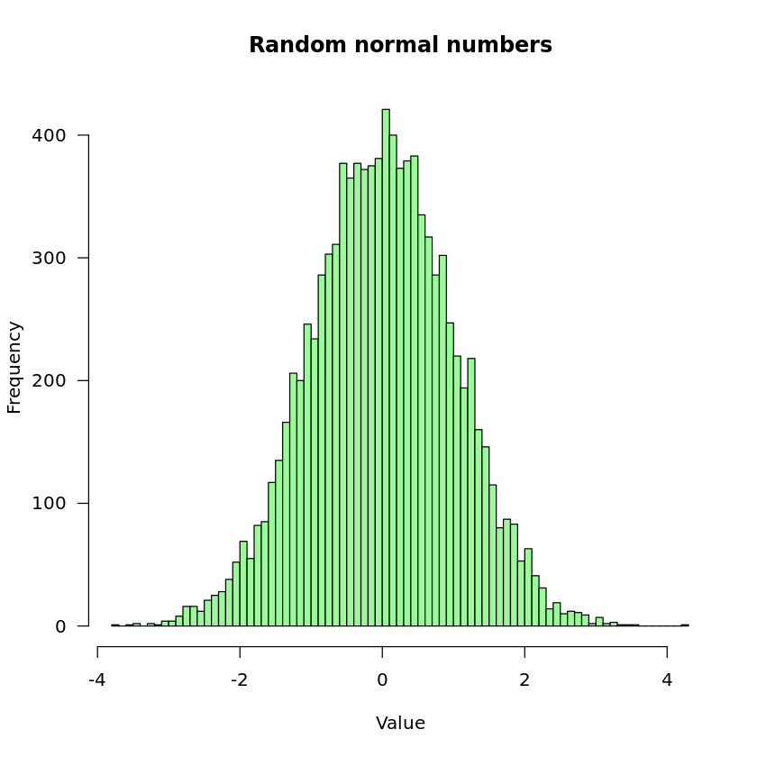

```
+++ distribution uniforme :
```

```
    Min.  1st Qu.   Median     Mean  3rd Qu.     Max.
0.001162 2.532793 5.020442 5.008554 7.470477 9.997819
```

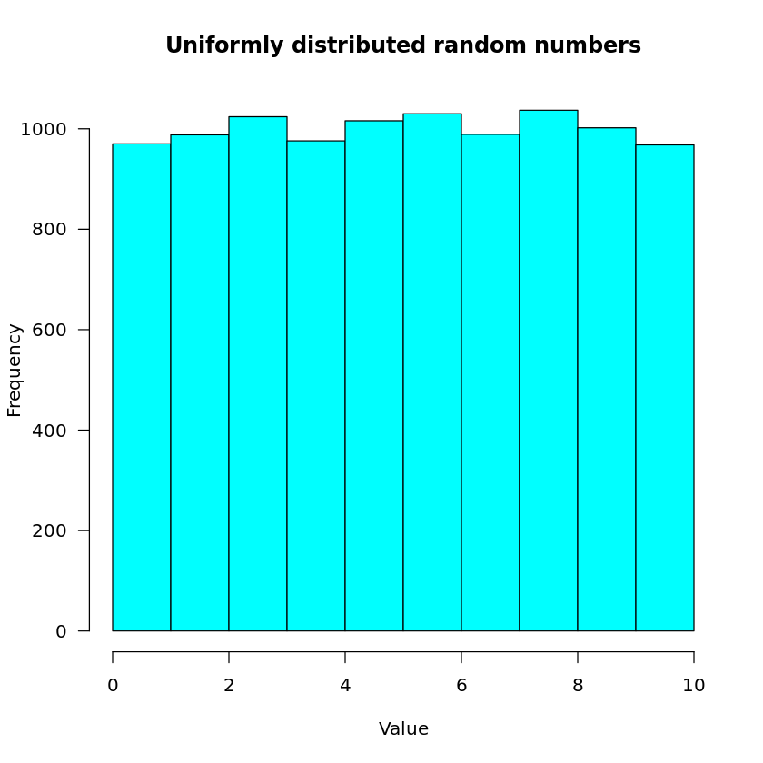

```r
hist(x = x1, breaks = 100,
     las = 1,
     col = "palegreen",
     main = "Random normal numbers",
     xlab = "Value"
     )
cat("+++ distribution normale :\n")
summary(x1)

hist(x = x2, breaks = 10,
     las = 1,
     col = "cyan",
     main = "Uniformly distributed random numbers",
     xlab = "Value"
     )
cat("+++ distribution uniforme :\n")
summary(x2)
```

### Exercice 2.2

Créez une matrice `m1` qui contient les 10 premières valeurs de `x1` (colonne 1 de `m1`) et les 10 dernières valeurs de `x2` (colonne 2 de `m1`). Verifiez qu’il s’agit bien d’une matrice et affichez ses dimensions.

**Tip :** *fonction recommandée : `matrix()`, `class()`, `dim()`, `cbind()`,…*

Voici une première solution en créant d'abord une matrice vide:

```r
## Prepare an empty matrix
m1 <- matrix(nrow = 10, ncol = 2)
m1

## Assign values to the first column
m1[, 1] <- x1[1:10]

## Assign values to the second column
m1[, 2] <- x1[9991:10000]

## Print the result rounded to 3 decimals
print(round(m1, digits = 3))
```

A matrix: 10 × 2 of type lgl

| NA | NA |
| --- | --- |
| NA | NA |
| NA | NA |
| NA | NA |
| NA | NA |
| NA | NA |
| NA | NA |
| NA | NA |
| NA | NA |
| NA | NA |

```
        [,1]   [,2]
 [1,] -1.511  0.227
 [2,] -1.386  0.306
 [3,]  0.149  0.120
 [4,]  0.447  1.156
 [5,] -1.357 -1.122
 [6,]  0.853 -1.210
 [7,]  1.267  0.773
 [8,]  1.724  0.321
 [9,]  0.673 -0.410
[10,] -0.717 -0.949
```

```r
## Check it is a matrix and print its dimensions
class(m1)
```

1. 'matrix'

2. 'array'

```r
print(dim(m1))
```

```
[1] 10  2
```

**=> Pour aller plus loin :**

```r
m1[, 1] <- head(x = x1, n = 10) # équivaut à m1[, 1] <- x1[1:10]
m1[, 2] <- tail(x = x1, n = 10) # éqivaut à m1[, 2] <- x1[9991:10000]
```

Cette seconde solution est plus efficace car elle utilise les vecteurs `x1` et `x2` directement avec la fonction `cbind()` sans passer par la création d'une matrice vide.

```r
m1 <- cbind(x1[1:10], x2[9991:10000])
print(round(m1, digits = 3))
```

```
        [,1]  [,2]
 [1,] -1.511 3.606
 [2,] -1.386 8.210
 [3,]  0.149 9.257
 [4,]  0.447 8.052
 [5,] -1.357 4.446
 [6,]  0.853 1.757
 [7,]  1.267 1.170
 [8,]  1.724 4.638
 [9,]  0.673 5.836
[10,] -0.717 6.362
```

```r
class(m1)
```

1. 'matrix'

2. 'array'

```r
print(dim(m1))
```

```
[1] 10  2
```

### Exercice 2.3

Créez une matrice `m2` qui contient

```
les 16ème, 51ème, 79ème, 31ème et 27ème valeurs de `x1` (colonne 1 de `m2`) et
les 30ème, 70ème, 12ème, 49ème et 45ème de `x2` (colonne 2 de `m2`).
```

Affichez `m2`.

**Tip :** *fonctions recommandées : `matrix()`, or `cbind()`, ...*

```r
m2 <- matrix(nrow = 5, ncol = 2)

## Assign values
m2[, 1] <- x1[c(16, 51, 79, 31, 27)]
m2[, 2] <- x2[c(30, 70, 12, 49, 45)]

## Print the result
print(m2)
```

```
            [,1]     [,2]
[1,]  0.82445157 2.949704
[2,]  1.41348726 3.305308
[3,]  1.15131819 4.913822
[4,] -0.03351272 5.233684
[5,] -1.72198802 3.758263
```

```r
## or more directly using the cbind() function without creating an empty matrix first
m2 <- cbind(x1[c(16, 51, 79, 31, 27)], x2[c(30, 70, 12, 49, 45)])
print(m2)
```

```
            [,1]     [,2]
[1,]  0.82445157 2.949704
[2,]  1.41348726 3.305308
[3,]  1.15131819 4.913822
[4,] -0.03351272 5.233684
[5,] -1.72198802 3.758263
```

### Exercice 2.4

Concaténez à la suite (l’une en dessous-de l’autre) les matrices `m1` et `m2`, afin d’obtenir une nouvelle matrice `m3`.

Quelles sont les dimensions (nombre de lignes et de colonnes) de `m3` ?

**Tip :** *fonctions recommandées : `rbind()`, `dim()`, `ncol()`, `nrow()`, `str()`*

```r
m3 <- rbind(m1, m2)
print(m3)
```

```
             [,1]     [,2]
 [1,] -1.51071607 3.605587
 [2,] -1.38563078 8.209903
 [3,]  0.14855485 9.256833
 [4,]  0.44738568 8.051581
 [5,] -1.35713468 4.445670
 [6,]  0.85312792 1.757235
 [7,]  1.26731626 1.169564
 [8,]  1.72366081 4.637662
 [9,]  0.67320983 5.836214
[10,] -0.71732032 6.361577
[11,]  0.82445157 2.949704
[12,]  1.41348726 3.305308
[13,]  1.15131819 4.913822
[14,] -0.03351272 5.233684
[15,] -1.72198802 3.758263
```

```r
# alternativement, moins belle, en utilisant matrix, et en emboitant  tout sans creer m1 et m2:
m3 <- matrix(c(x1[1:10],
               (x2[1:10]),
               x1[c(16, 51, 79, 31, 27)],
               (x2[c(30, 70, 12, 49, 45)])),
             nrow = 15,
             ncol = 2,
             byrow = TRUE)
```

```r
print(dim(m3))
```

```
[1] 15  2
```

```r
# ou vous pouviez utiliser nrow() et ncol()
nrow(m3)
ncol(m3)
```

15

2

**=> Pour aller plus loin :**

Les operateurs classiques (+, -, * ) font des operations terme à terme si les deux matrices ont la même taille, par exemple: `m1 + rbind(m2,m2)` alors que `m1+m2` retourne une erreur.

Quelques exemples:

```r
m4 <- m1 %*% t(m2)# m1 avec la transposée de m2 qui a 2 lignes et 5 colonnes
print(dim(m4))
```

```
[1] 10  5
```

```r
m5 <- m1 %*% t(m1)# m1 avec sa propre tranposée
print(dim(m5))
```

```
[1] 10 10
```

```r
m6 <- t(m1) %*% m1 # ou l'inverse! Pas de commutativite sur ces calculs!
print(dim(m6))
```

```
[1] 2 2
```

## Exercice 3 : exploration des données d'une matrice

### Exercice 3.1

Importez dans votre session R les données nommées `WorldPhones` (pré-existantes dans R).

Affichez le contenu de la variable `WorldPhones`.

Quelle est sa structure et sa classe ?

**Tip :** *fonctions recommandées : `data(WorldPhones)`, `class()`, `dim()`, `str()`*

```r
data("WorldPhones")
```

```r
WorldPhones
```

A matrix: 7 × 7 of type dbl

|  | N.Amer | Europe | Asia | S.Amer | Oceania | Africa | Mid.Amer |
| --- | --- | --- | --- | --- | --- | --- | --- |
| 1951 | 45939 | 21574 | 2876 | 1815 | 1646 | 89 | 555 |
| 1956 | 60423 | 29990 | 4708 | 2568 | 2366 | 1411 | 733 |
| 1957 | 64721 | 32510 | 5230 | 2695 | 2526 | 1546 | 773 |
| 1958 | 68484 | 35218 | 6662 | 2845 | 2691 | 1663 | 836 |
| 1959 | 71799 | 37598 | 6856 | 3000 | 2868 | 1769 | 911 |
| 1960 | 76036 | 40341 | 8220 | 3145 | 3054 | 1905 | 1008 |
| 1961 | 79831 | 43173 | 9053 | 3338 | 3224 | 2005 | 1076 |

```r
class(WorldPhones)
```

1. 'matrix'

2. 'array'

```r
print(dim(WorldPhones))
```

```
[1] 7 7
```

```r
str(WorldPhones)
```

```
 num [1:7, 1:7] 45939 60423 64721 68484 71799 ...
 - attr(*, "dimnames")=List of 2
  ..$ : chr [1:7] "1951" "1956" "1957" "1958" ...
  ..$ : chr [1:7] "N.Amer" "Europe" "Asia" "S.Amer" ...
```

### Exercice 3.2

Calculez le nombre total de numéros de téléphone attribués :

- au cours des différentes années (vecteur `nbrTelAn`)
- pour chaque continent (vecteur `nbrTelCont`)

**Tip :** *fonction recommandée : `sum()`, `apply()`*

```r
# nombre d'appels pour le continent 1
sum(WorldPhones[,1])
```

467233

```r
# nombre d'appels pour le continent 2
sum(WorldPhones[,2])
```

240404

etc...

**=> Pour aller plus loin :**

Pour aller plus rapidement, on utilise la fonction `apply()` qui est très utile pour répéter une commande par ligne ou colonne sur une matrice:

```r
# repetition de la commande sum() en ligne = marginal sums per year
nbrTelAn <- apply(WorldPhones, 1, sum)
print(nbrTelAn)
```

```
  1951   1956   1957   1958   1959   1960   1961
 74494 102199 110001 118399 124801 133709 141700
```

```r
# repetition de la commande sum() en colonne =  marginal sums per continent
nbrTelCont <- apply(WorldPhones, 2, sum)
print(nbrTelCont)
```

```
  N.Amer   Europe     Asia   S.Amer  Oceania   Africa Mid.Amer
  467233   240404    43605    19406    18375    10388     5892
```

### Exercice 3.3

Quel est le continent qui a le plus / moins de numéros attribués ?

**Tip :** *fonctions recommandées : `names()`, `which()`, `max()`, `min()`, `which.max()`, `which.min()`*

```r
# continent avec le plus de numeros
names(nbrTelCont)[which(nbrTelCont == max(nbrTelCont))]
```

'N.Amer'

```r
# continent avec le moins de numeros
names(nbrTelCont)[which(nbrTelCont == min(nbrTelCont))]
```

'Mid.Amer'

```r
# ou plus simplement avec la commande which.max() ou which.min()
names(which.max(nbrTelCont))
```

'N.Amer'

```r
names(which.min(nbrTelCont))
```

'Mid.Amer'

**=> Pour aller plus loin :**

Une autre façon en utilisant les fonctions `tail()`et `head()` après avoir trié les comptes avec `sort()`

```r
tail(sort(nbrTelCont), n = 1)
```

**N.Amer:** 467233

### Exercice 3.4

Dans combien de continents y a-t-il plus de : 20.000, 50.000 et 200.000 numéros de téléphone attribués ?

**Tip :** *fonctions recommandées : `sum()`*

```r
cat("Il y a plus de 20 000 numéros attribués dans", sum(nbrTelCont > 20000), "continents. \n") # la phrase n'était pas demandée dans l'exrecice.
cat("Il y a plus de 50 000 numéros attribués dans", sum(nbrTelCont > 50000), "continents. \n")
cat("Il y a plus de 200 000 numéros attribués dans", sum(nbrTelCont > 200000), "continents. \n")
```

```
Il y a plus de 20 000 numéros attribués dans 3 continents.
Il y a plus de 50 000 numéros attribués dans 2 continents.
Il y a plus de 200 000 numéros attribués dans 2 continents.
```

A la fin, je sauve la liste comme objet pour de futures sessions dans R.

```r
ls()
save.image(file="R2_practice.RData")
```

1. 'm1'

2. 'm2'

3. 'm3'

4. 'm4'

5. 'm5'

6. 'm6'

7. 'matAleatoire'

8. 'matIdentite'

9. 'my_mat'

10. 'my_mat2'

11. 'my_vector'

12. 'n'

13. 'nbrTelAn'

14. 'nbrTelCont'

15. 'vec1'

16. 'vec2'

17. 'vec3'

18. 'WorldPhones'

19. 'x1'

20. 'x2'

## Check list des actions avant la prochaine session R:

*Pour cocher les cases, ouvrez la cellule du notebook et remplacez l'espace entre les crochets par un `x` lorsque l'action est effectuée*

[ ] relire le cours et revoir les différents supports dont diapos, vidéos, scripts et notebooks

[ ] faire les exercices sans les corrections

[ ] lire et comprendre les corrections

[ ] refaire les exercices sans les corrections

[ ] étudier le tutorial d'introduction aux dataframes "R2_tuto_intro2dataframes" (.ipynb et .html sur moodle) et regarder le diaporama correspondant

[ ] continuer les tuto de swirl 1, 3 à 6 à votre rythme pour les avoir finis avant le QCM en séance R#4.

[ ] visionner video Fil Rouge pour le 28/09 avant le TP6 Unix#4

## Useful commands

- `CTRL`+`S` : save notebook  
- `CTRL`+`ENTER` : Run Cell  
- `SHIFT`+`ENTER` : Run Cell and Select Next  
- `ALT`+`ENTER` : Run Cell and Insert Below  
- `ESC`+`y` : Change to *Code* Cell Type  
- `ESC`+`m` : Change to *Markdown* Cell Type  
- `ESC`+`r` : Change to *Raw* Cell Type  
- `ESC`+`a` : Create Cell Above  
- `ESC`+`b` : Create Cell Below  
To make nice html reports with markdown: [html visualization tool 1](https://dillinger.io/) or [html visualization tool 2](https://stackedit.io/app#), [to draw nice tables](https://www.tablesgenerator.com/markdown_tables), and the [Ultimate guide](https://medium.com/analytics-vidhya/the-ultimate-markdown-guide-for-jupyter-notebook-d5e5abf728fd).  
Further reading on JupyterLab notebooks: [Jupyter Lab documentation](https://jupyterlab.readthedocs.io/en/latest/user/notebook.html).

*=> About this jupyter notebook*

This a jupyter notebook in **R**, meaning that the commands you will enter or run in `Code` cells are directly understood by the server in the R language.  
You could run the same commands in a Terminal or in RStudio.

## Here we are using JupyterLab interface implemented as part of the https://plasmabio.org/ project lead by Sandrine Caburet, Pierre Poulain and Claire Vandiedonck.

[version 23/09/2022 - last revision: @CVandiedonck]